# working with text with `stringr`

Author

Casey Schine adapted from Violet Ross

```r
#LOAD PACKAGES
library(tidyverse)
library(stringr)
library(ggthemes)
```

## A few basics

**What is a string?**

A string is a data type used to represent text. In R, we indicate that something is a string by referring to it with quotes.

Examples of strings:

- Rwanda
- #11111
- 1w3r
- 1999_1

NOT a string:

- 1999

**What is** `stringr` **?**

stringr is a package containing a bunch of functions that help us work with strings.

[**stringr cheat sheet**](https://evoldyn.gitlab.io/evomics-2018/ref-sheets/R_strings.pdf)

# Using `stringr`

**I’m registering for classes for this Fall and am trying to decide which courses to take.**

Let’s look at the course catalog!

Read in the courses data.

```r
# Download the courses.csv dataset

# you will need to put in your own filepath here
# !!!!!!!!!!!!!!!!!!!!!!!!!!!!!!!!!!!!!!!!!!!!!!!!!!!!!!!
courses <- read_csv("~/Dropbox/!Middlebury/Teaching/STAT 118/S2026/S2026_R_Proj/data/courses.csv")
# !!!!!!!!!!!!!!!!!!!!!!!!!!!!!!!!!!!!!!!!!!!!!!!!!!!!!!!

view(courses)
```

## `str_detect`

**inputs**:

- a string (or a column of strings) to search *from*
- a string to search *for*

**output**: boolean value (TRUE or FALSE)

little example:

```r
# using str_detect to search for strings
# for the string "Welcome to data science, look at this cool data"

#find the pattern "data"

str_detect("Welcome to data science, look at this cool data", "data")
```

```
[1] TRUE
```

```r
# find the pattern "pineapple"
str_detect("Welcome to data science, look at this cool data", "pineapple")
```

```
[1] FALSE
```

I only want to take classes in Warner! Let’s filter for rows where we **detect** the word “Warner” in the `location` column.

```r
# filter for where the location column contains the pattern "WNS"
# use str_detect() inside filter(), on the location column
# save as new object to take a closer look

warner_courses <- courses |>
  filter(str_detect(location, "WNS"))

warner_courses
```

```
# A tibble: 48 × 9
   titles      distros department time  location professor description courseNum
   <chr>       <chr>   <chr>      <chr> <chr>    <chr>     <chr>       <chr>
 1 Beginning … LNG     Chinese    8:40… "Warner… Hang Du … "\nThis co… CHNS0101…
 2 Beginning … LNG     Chinese    9:45… "Warner… Hang Du … "\nThis co… CHNS0101…
 3 Economic S… DED     Economics  12:4… "Warner… Erick Go… "\nAn intr… ECON0111…
 4 Introducto… SOC     Economics  9:45… "Warner… David Mu… "\nAn intr… ECON0150…
 5 Introducto… SOC     Economics  11:1… "Warner… David Mu… "\nAn intr… ECON0150…
 6 Introducto… SOC     Economics  8:15… "Warner… Cihan Ar… "\nAn intr… ECON0150…
 7 Introducto… SOC     Economics  2:15… "Warner… <NA>      "\nAn intr… ECON0150…
 8 Introducto… SOC     Economics  2:15… "Warner… Phani Wu… "\nAn intr… ECON0155…
 9 Introducti… DED     Economics  9:45… "Warner… German R… "\nIn this… ECON0211…
10 Introducti… DED     Economics  11:1… "Warner… German R… "\nIn this… ECON0211…
# ℹ 38 more rows
# ℹ 1 more variable: meet <chr>
```

```r
# look at what str_detect actually outputs in column
# mutate on a new column using str_detect()
# save as new object again

warner_courses <- courses |>
  mutate(warner_class = str_detect(location, "WNS")) |>
  select(titles, department, location, warner_class)

warner_courses
```

```
# A tibble: 568 × 4
   titles                                       department location warner_class
   <chr>                                        <chr>      <chr>    <lgl>
 1 Cultural Community Collaboration & Producti… Program i… "Wright… FALSE
 2 Immigrant America                            Program i… "Axinn … FALSE
 3 Introduction to Latina/o Studies             Program i… "Axinn … FALSE
 4 See the U.S.A.: The History of Tourism in A… Program i… "Axinn … FALSE
 5 Science Fiction                              Program i… "Axinn … FALSE
 6 Music and Social Power in American Culture   Program i… "Axinn … FALSE
 7 <NA>                                         Program i… "Axinn … FALSE
 8 Viewer Discretion Advised: Controversies in… Program i… "Axinn … FALSE
 9 Posthuman Medicine: Morals, Machines, and B… Program i… "Axinn … FALSE
10 Humanitarian Visas in Vermont and Beyond     Program i… "Axinn … FALSE
# ℹ 558 more rows
```

Suppose I don’t want any classes on Friday. Let’s use `str_detect` to find our options.

```r
# look for instances of the pattern "Friday" in the meet column
# using !str_detect()
# filter them out based on the meet column

nofriday_classes <- courses |>
  filter(!str_detect(meet, "Friday")) |>
  select(titles, department, time, location, meet)

nofriday_classes
```

```
# A tibble: 461 × 5
   titles                                        department time  location meet
   <chr>                                         <chr>      <chr> <chr>    <chr>
 1 Cultural Community Collaboration & Production Program i… 2:15… "Wright… Wedn…
 2 Immigrant America                             Program i… 11:1… "Axinn … Tues…
 3 Introduction to Latina/o Studies              Program i… 7:30… "Axinn … Wedn…
 4 See the U.S.A.: The History of Tourism in Am… Program i… 11:1… "Axinn … Tues…
 5 Science Fiction                               Program i… 2:15… "Axinn … Tues…
 6 Music and Social Power in American Culture    Program i… 9:45… "Axinn … Mond…
 7 <NA>                                          Program i… 9:45… "Axinn … Tues…
 8 Viewer Discretion Advised: Controversies in … Program i… 2:15… "Axinn … Tues…
 9 Posthuman Medicine: Morals, Machines, and Bo… Program i… 11:1… "Axinn … Tues…
10 Humanitarian Visas in Vermont and Beyond      Program i… 12:4… "Axinn … Tues…
# ℹ 451 more rows
```

```r
# we can do the same thing using the negate argument in str_detect
# by setting negate=TRUE inside of str_detect()

nofriday_classes <- courses |>
  filter(str_detect(meet, "Friday", negate=TRUE)) |>
  select(titles, department, time, location, meet)

nofriday_classes
```

```
# A tibble: 461 × 5
   titles                                        department time  location meet
   <chr>                                         <chr>      <chr> <chr>    <chr>
 1 Cultural Community Collaboration & Production Program i… 2:15… "Wright… Wedn…
 2 Immigrant America                             Program i… 11:1… "Axinn … Tues…
 3 Introduction to Latina/o Studies              Program i… 7:30… "Axinn … Wedn…
 4 See the U.S.A.: The History of Tourism in Am… Program i… 11:1… "Axinn … Tues…
 5 Science Fiction                               Program i… 2:15… "Axinn … Tues…
 6 Music and Social Power in American Culture    Program i… 9:45… "Axinn … Mond…
 7 <NA>                                          Program i… 9:45… "Axinn … Tues…
 8 Viewer Discretion Advised: Controversies in … Program i… 2:15… "Axinn … Tues…
 9 Posthuman Medicine: Morals, Machines, and Bo… Program i… 11:1… "Axinn … Tues…
10 Humanitarian Visas in Vermont and Beyond      Program i… 12:4… "Axinn … Tues…
# ℹ 451 more rows
```

```r
# Do with lowercase friday
# this doesn't work because the string is not an exact match due to difference in case

nofriday_classes <- courses |>
  filter(str_detect(meet, "friday", negate=TRUE)) |>
  select(titles, department, time, location, meet)

nofriday_classes
```

```
# A tibble: 568 × 5
   titles                                        department time  location meet
   <chr>                                         <chr>      <chr> <chr>    <chr>
 1 Cultural Community Collaboration & Production Program i… 2:15… "Wright… Wedn…
 2 Immigrant America                             Program i… 11:1… "Axinn … Tues…
 3 Introduction to Latina/o Studies              Program i… 7:30… "Axinn … Wedn…
 4 See the U.S.A.: The History of Tourism in Am… Program i… 11:1… "Axinn … Tues…
 5 Science Fiction                               Program i… 2:15… "Axinn … Tues…
 6 Music and Social Power in American Culture    Program i… 9:45… "Axinn … Mond…
 7 <NA>                                          Program i… 9:45… "Axinn … Tues…
 8 Viewer Discretion Advised: Controversies in … Program i… 2:15… "Axinn … Tues…
 9 Posthuman Medicine: Morals, Machines, and Bo… Program i… 11:1… "Axinn … Tues…
10 Humanitarian Visas in Vermont and Beyond      Program i… 12:4… "Axinn … Tues…
# ℹ 558 more rows
```

Perhaps I’m interested in immigration. We can use `str_detect` to find course descriptions that mention immigration.

The `regex` function is used to write regular expressions in R. Regular expressions are helpful if you want to search for a pattern rather than a specific word or phrase.  
For now, we will only use regex to ignore capitalization. If you’re interested in using regular expressions at some point, this [regex cheat sheet](https://cheatography.com/davechild/cheat-sheets/regular-expressions/) will be super helpful.

```r
# filter for class descriptions that contain the pattern "immigration" using str_detect() on the description column
# use regex to ignore upper versus lower case as: regex("immigration", ignore_case=TRUE)

immigration_courses <- courses |>
  filter(str_detect(description, regex("immigration", ignore_case=TRUE))|
           str_detect(titles, regex("immigration", ignore_case=TRUE))) |>
  select(titles, department, time, description)

immigration_courses
```

```
# A tibble: 8 × 4
  titles                                           department  time  description
  <chr>                                            <chr>       <chr> <chr>
1 Immigrant America                                Program in… 11:1… "\nIn this…
2 Globalization and US Inequality                  Economics   12:4… "\nDoes gl…
3 American Superheroes and Immigration             First-Year… 1:10… "\nIn this…
4 Introduction to International and Global Studies Internatio… 11:1… "\nThis is…
5 An Introduction to Contemporary Italy            Italian     9:45… "\nIntende…
6 An Introduction to Contemporary Italy            Italian     11:1… "\nIntende…
7 Globalization, Terrorism, and Global Insurgency  Political … 9:45… "\nHow doe…
8 Christianity and Social Justice in the U.S.      Religion    1:30… "\nReligio…
```

## `str_extract` and `str_remove`

**str_extract inputs**:

- a string (or a column of strings) to extract *from*
- a string to extract

**str_extract output**: the string you wanted to extract OR nothing

**str_remove inputs**:

- a string (or a column of strings) to remove stuff *from*
- a string to remove

**str_remove output**: the first input string with the second input removed

little example:

```r
# for the string "Welcome to data science, look at this cool data"
# and the pattern "data"

# str_extract() extracts first instance

str_extract("Welcome to data science, look at this cool data", "data")
```

```
[1] "data"
```

```r
# str_extract_all() extracts all instances

str_extract_all("Welcome to data science, look at this cool data", "data")
```

```
[[1]]
[1] "data" "data"
```

```r
# str_remove() removes first instance

str_remove("Welcome to data science, look at this cool data", "data")
```

```
[1] "Welcome to  science, look at this cool data"
```

```r
# str_remove_all() removes all instances
str_remove_all("Welcome to data science, look at this cool data", "data")
```

```
[1] "Welcome to  science, look at this cool "
```

CW is part of the distribution requirement column. I want CW to be its own column. First we can create a new column called `isCW` by **extracting** instances of “CW” from the `distros` column in each row. Then we can **remove** all instances of “CW” from the `distros` column.

```r
# make new column that states whether a course is CW or not
# use str_extract on the distros column for the pattern "CW"

CW_courses <- courses |>
  mutate(isCW = str_extract(distros, "CW")) |>
  select(titles, department, distros, location, isCW)

CW_courses
```

```
# A tibble: 568 × 5
   titles                                      department distros location isCW
   <chr>                                       <chr>      <chr>   <chr>    <chr>
 1 Cultural Community Collaboration & Product… Program i… <NA>    "Wright… <NA>
 2 Immigrant America                           Program i… AMR HIS "Axinn … <NA>
 3 Introduction to Latina/o Studies            Program i… AMR HI… "Axinn … <NA>
 4 See the U.S.A.: The History of Tourism in … Program i… AMR CW… "Axinn … CW
 5 Science Fiction                             Program i… LIT     "Axinn … <NA>
 6 Music and Social Power in American Culture  Program i… CMP LIT "Axinn … <NA>
 7 <NA>                                        Program i… AMR AR… "Axinn … CW
 8 Viewer Discretion Advised: Controversies i… Program i… AMR AR… "Axinn … <NA>
 9 Posthuman Medicine: Morals, Machines, and … Program i… LIT     "Axinn … <NA>
10 Humanitarian Visas in Vermont and Beyond    Program i… AMR     "Axinn … <NA>
# ℹ 558 more rows
```

```r
# now make a new column for distros and remove CW using str_remove()

CW_courses <- CW_courses |>
  mutate(distros=str_remove(distros, "CW")) |>
  select(titles, department, distros, location, isCW)

CW_courses
```

```
# A tibble: 568 × 5
   titles                                      department distros location isCW
   <chr>                                       <chr>      <chr>   <chr>    <chr>
 1 Cultural Community Collaboration & Product… Program i… <NA>    "Wright… <NA>
 2 Immigrant America                           Program i… AMR HIS "Axinn … <NA>
 3 Introduction to Latina/o Studies            Program i… AMR HI… "Axinn … <NA>
 4 See the U.S.A.: The History of Tourism in … Program i… AMR  H… "Axinn … CW
 5 Science Fiction                             Program i… LIT     "Axinn … <NA>
 6 Music and Social Power in American Culture  Program i… CMP LIT "Axinn … <NA>
 7 <NA>                                        Program i… AMR AR… "Axinn … CW
 8 Viewer Discretion Advised: Controversies i… Program i… AMR AR… "Axinn … <NA>
 9 Posthuman Medicine: Morals, Machines, and … Program i… LIT     "Axinn … <NA>
10 Humanitarian Visas in Vermont and Beyond    Program i… AMR     "Axinn … <NA>
# ℹ 558 more rows
```

```r
# count the number of CW courses

CW_courses |>
  count(isCW)
```

```
# A tibble: 2 × 2
  isCW      n
  <chr> <int>
1 CW       71
2 <NA>    497
```

## `str_sub`

**str_sub inputs**:

- a string (or a column of strings) take substrings of
- where the substring should start
- where the substring should end

**str_sub output**: the substring

little example:

```r
#extract the pieces of a string using str_sub() function
# extract the substring "data science"
# from the sentence "Welcome to data science, look at this cool data"
# need to define the position of the start character and the end character by their position in the string

str_sub("Welcome to data science, look at this cool data",
        start=12, end=23)
```

```
[1] "data science"
```

```r
# move the start and end to extract a different string
# the default end is the end of the string

str_sub("Welcome to data science, look at this cool data",
        start=26)
```

```
[1] "look at this cool data"
```

Maybe I only want 200 level math and stats classes.  
First we filter for just math/stats classes. Then we can create a new column called `level` that contains only the sixth character from the `courses` column.

We can then filter our `level` column for specific course levels.

```r
# first let's get all of the exact department names
courses |>
  distinct(department) |>
  filter(str_detect(department, "Math"))
```

```
# A tibble: 2 × 1
  department
  <chr>
1 Mathematics & Statistics
2 Mathematics
```

```r
# filter for only math/stats classes using str_detect()
# mutate on a column called level that extracts the 6th character from courseNum column
# filter for only level==2

math_courses_200 <- courses |>
  filter(department=="Mathematics & Statistics") |>
  mutate(level=str_sub(courseNum, start=6, end=6)) |>
  filter(level==2) |>
  select(titles, department, courseNum, level)


math_courses_200
```

```
# A tibble: 10 × 4
   titles                                        department      courseNum level
   <chr>                                         <chr>           <chr>     <chr>
 1 Linear Algebra                                Mathematics & … MATH0200… 2
 2 Linear Algebra                                Mathematics & … MATH0200… 2
 3 Linear Algebra                                Mathematics & … MATH0200… 2
 4 Linear Algebra                                Mathematics & … MATH0200… 2
 5 Multivariable Calculus                        Mathematics & … MATH0223… 2
 6 Multivariable Calculus                        Mathematics & … MATH0223… 2
 7 <NA>                                          Mathematics & … MATH0226… 2
 8 Introduction to Statistical and Data Sciences Mathematics & … STAT0201… 2
 9 Introduction to Statistical and Data Sciences Mathematics & … STAT0201… 2
10 Statistical Learning                          Mathematics & … STAT0218… 2
```

```r
# filter for 200 level classes without mutating first
# use str_sub() inside of filter

math_courses_200 <- courses |>
  filter(department=="Mathematics & Statistics") |>
  filter((str_sub(courseNum, start=6, end=6))==2) |>
  select(titles, department, courseNum)

math_courses_200
```

```
# A tibble: 10 × 3
   titles                                        department            courseNum
   <chr>                                         <chr>                 <chr>
 1 Linear Algebra                                Mathematics & Statis… MATH0200…
 2 Linear Algebra                                Mathematics & Statis… MATH0200…
 3 Linear Algebra                                Mathematics & Statis… MATH0200…
 4 Linear Algebra                                Mathematics & Statis… MATH0200…
 5 Multivariable Calculus                        Mathematics & Statis… MATH0223…
 6 Multivariable Calculus                        Mathematics & Statis… MATH0223…
 7 <NA>                                          Mathematics & Statis… MATH0226…
 8 Introduction to Statistical and Data Sciences Mathematics & Statis… STAT0201…
 9 Introduction to Statistical and Data Sciences Mathematics & Statis… STAT0201…
10 Statistical Learning                          Mathematics & Statis… STAT0218…
```

## `str_replace`

str_replace inputs:

- A string (or column of strings) to modify
- A pattern to find
- The text that should replace the pattern

str_replace output: A string with the first matching pattern replaced.

```r
# in the phrase "Welcome to data science, look at this cool data"
# replace the first instance of "data" with "statistics" using str_replace()

str_replace("Welcome to data science, look at this cool data",
            "data", "pineapple")
```

```
[1] "Welcome to pineapple science, look at this cool data"
```

```r
# replace ALL instances of "data" using str_replace_all
str_replace_all("Welcome to data science, look at this cool data",
            "data", "pineapple")
```

```
[1] "Welcome to pineapple science, look at this cool pineapple"
```

Notice that str_replace() only changes the first match, while str_replace_all() changes every match.

**Cleaning up our course locations**

Sometimes datasets contain abbreviations or inconsistent names for the same thing. A good example of this would be the different country names in our Joining Homework. This can cause problems when we’re grouping, counting, or joining observations.

Let’s look at the locations in our course catalog.

```r
courses |>
  distinct(location)
```

```
# A tibble: 103 × 1
   location
   <chr>
 1 "Wright Memorial Theater SEM (WTH SEM)\n"
 2 "Axinn Center 219 (AXN 219)\n"
 3 "Axinn Center 104 (AXN 104)\n"
 4 "Axinn Center 220 (AXN 220)\n"
 5 "Axinn Center 229 (AXN 229)\n"
 6 "Munroe Hall 311 (MNR 311)\n"
 7 "Munroe Hall 409 (MNR 409)\n"
 8 "Munroe Hall 217 (MNR 217)\n"
 9 "Munroe Hall 317 (MNR 317)\n"
10 "Mahaney Center for the Arts 125 (MAC 125)\n"
# ℹ 93 more rows
```

We know that `WNS` refers to Warner. Suppose we want to replace that abbreviation with the full building name.

```r
# use str_replace_all() to replace "WNS" with "Warner" in the location column
# inside of a mutate()

warner_courses <- courses |>
  mutate(location=str_replace(location, "WNS", "Warner")) |>
  select(titles, department, location)

warner_courses
```

```
# A tibble: 568 × 3
   titles                                                    department location
   <chr>                                                     <chr>      <chr>
 1 Cultural Community Collaboration & Production             Program i… "Wright…
 2 Immigrant America                                         Program i… "Axinn …
 3 Introduction to Latina/o Studies                          Program i… "Axinn …
 4 See the U.S.A.: The History of Tourism in American Cultu… Program i… "Axinn …
 5 Science Fiction                                           Program i… "Axinn …
 6 Music and Social Power in American Culture                Program i… "Axinn …
 7 <NA>                                                      Program i… "Axinn …
 8 Viewer Discretion Advised: Controversies in American Art… Program i… "Axinn …
 9 Posthuman Medicine: Morals, Machines, and Bodies          Program i… "Axinn …
10 Humanitarian Visas in Vermont and Beyond                  Program i… "Axinn …
# ℹ 558 more rows
```

```r
# check the results

warner_courses <- warner_courses |>
  filter(str_detect(location, "Warner"))


warner_courses
```

```
# A tibble: 48 × 3
   titles                                   department location
   <chr>                                    <chr>      <chr>
 1 Beginning Chinese                        Chinese    "Warner Hall 010 (Warner…
 2 Beginning Chinese                        Chinese    "Warner Hall 010 (Warner…
 3 Economic Statistics (formerly ECON 0210) Economics  "Warner Hall 100 (Warner…
 4 Introductory Macroeconomics              Economics  "Warner Hall 104 (Warner…
 5 Introductory Macroeconomics              Economics  "Warner Hall 104 (Warner…
 6 Introductory Macroeconomics              Economics  "Warner Hall 100 (Warner…
 7 Introductory Macroeconomics              Economics  "Warner Hall 104 (Warner…
 8 Introductory Microeconomics              Economics  "Warner Hall 100 (Warner…
 9 Introduction to Regression Analysis      Economics  "Warner Hall 100 (Warner…
10 Introduction to Regression Analysis      Economics  "Warner Hall 100 (Warner…
# ℹ 38 more rows
```

We can also replace abbreviations without overwriting the original column.

```r
# same thing but save it to a new column

warner_courses <- courses |>
  mutate(location_long=str_replace(location, "WNS", "Warner")) |>
  filter(str_detect(location_long, "Warner")) |>
  select(titles, department, location, location_long)

warner_courses
```

```
# A tibble: 48 × 4
   titles                                   department location    location_long
   <chr>                                    <chr>      <chr>       <chr>
 1 Beginning Chinese                        Chinese    "Warner Ha… "Warner Hall…
 2 Beginning Chinese                        Chinese    "Warner Ha… "Warner Hall…
 3 Economic Statistics (formerly ECON 0210) Economics  "Warner Ha… "Warner Hall…
 4 Introductory Macroeconomics              Economics  "Warner Ha… "Warner Hall…
 5 Introductory Macroeconomics              Economics  "Warner Ha… "Warner Hall…
 6 Introductory Macroeconomics              Economics  "Warner Ha… "Warner Hall…
 7 Introductory Macroeconomics              Economics  "Warner Ha… "Warner Hall…
 8 Introductory Microeconomics              Economics  "Warner Ha… "Warner Hall…
 9 Introduction to Regression Analysis      Economics  "Warner Ha… "Warner Hall…
10 Introduction to Regression Analysis      Economics  "Warner Ha… "Warner Hall…
# ℹ 38 more rows
```

This is often a good idea when cleaning data because it allows us to compare the original values with the cleaned values.

## `separate_wider_delim`

Sometimes a single column contains multiple pieces of information that we want to analyze separately.

`separate_wider_delim()` allows us to split a column into multiple columns based on a **delimiter** (a character that separates pieces of text, such as a space, comma, or underscore).

**inputs**:

- A dataframe
- The column containing the strings we want to separate
- The delimiter (`delim`) that separates the pieces
- The names of the new columns (`names`)

**output**: A dataframe with the original column separated into new columns.

```r
# create a small example dataset
example_courses <- tibble(course = c("STAT_0118", "BIOL_0140", "CHEM_0103"))

example_courses
```

```
# A tibble: 3 × 1
  course
  <chr>
1 STAT_0118
2 BIOL_0140
3 CHEM_0103
```

```r
# separate the course into department and course number
# define the column to be parsed with cols=column_name,
# define the delimeter using delim = ""
# define the names of the new columns using names=c("new_name1", new_name2")

example_courses |>
separate_wider_delim(course, delim="_",
                     names=c("dept", "coursenum"))
```

```
# A tibble: 3 × 2
  dept  coursenum
  <chr> <chr>
1 STAT  0118
2 BIOL  0140
3 CHEM  0103
```

Notice that the original `course` column has been replaced by two new columns.

What happens if we want to keep the original column?

```r
# Do the same thing, but set cols_remove=FALSE to keep the original column
example_courses |>
separate_wider_delim(course, delim="_",
                     names=c("dept", "coursenum"),
                     cols_remove=FALSE)
```

```
# A tibble: 3 × 3
  dept  coursenum course
  <chr> <chr>     <chr>
1 STAT  0118      STAT_0118
2 BIOL  0140      BIOL_0140
3 CHEM  0103      CHEM_0103
```

#### Let’s try it with our courses

Before separating a column, we need to understand how the information is organized.

Let’s look at the `time` column.

Each course is given a start time and an end time. We can separate these into 2 different columns.

```r
course_times <- courses |>
  separate_wider_delim(time, "-",
                       names=c("start_time", "end_time"),
                       cols_remove=FALSE) |>
  select(titles, department, location, start_time, end_time, time)

course_times
```

```
# A tibble: 568 × 6
   titles                          department location start_time end_time time
   <chr>                           <chr>      <chr>    <chr>      <chr>    <chr>
 1 Cultural Community Collaborati… Program i… "Wright… 2:15pm     3:30pm   2:15…
 2 Immigrant America               Program i… "Axinn … 11:15am    12:30pm  11:1…
 3 Introduction to Latina/o Studi… Program i… "Axinn … 7:30pm     10:25pm  7:30…
 4 See the U.S.A.: The History of… Program i… "Axinn … 11:15am    12:30pm  11:1…
 5 Science Fiction                 Program i… "Axinn … 2:15pm     3:30pm   2:15…
 6 Music and Social Power in Amer… Program i… "Axinn … 9:45am     11:00am  9:45…
 7 <NA>                            Program i… "Axinn … 9:45am     11:00am  9:45…
 8 Viewer Discretion Advised: Con… Program i… "Axinn … 2:15pm     3:30pm   2:15…
 9 Posthuman Medicine: Morals, Ma… Program i… "Axinn … 11:15am    12:30pm  11:1…
10 Humanitarian Visas in Vermont … Program i… "Axinn … 12:45pm    2:00pm   12:4…
# ℹ 558 more rows
```

`separate_wider_delim()` works best when the text follows a consistent pattern. Before separating a column, we should inspect its values to make sure our delimiter will work as expected.

## `str_count`

**str_count inputs**:

- a string (or a column of strings) to count *from*
- a string you want to count the number of instances of

**str_count output**: the number of times the second string occurs in your first string

little example:

```r
# count the instance of the word "data" in the sentence "Welcome to data science, look at this cool data"
# using str_count()

str_count("Welcome to data science, look at this cool data", "data")
```

```
[1] 2
```

```r
# count the word "look"

str_count("Welcome to data science, look at this cool data", "look")
```

```
[1] 1
```

Maybe I only want my classes to meet twice a week. Let’s **count** how many times “day” appears in the `meet` column and put this value in a new column called `day_count`. `day_count` represents how many days a week a class meets.

```r
# mutate on a column called day_count using str_count() for the meet column, looking for instances of the string "day"

daycount_courses <- courses |>
  mutate(day_count=str_count(meet, "day")) |>
  select(titles, department, location, meet, day_count)

daycount_courses
```

```
# A tibble: 568 × 5
   titles                                    department location meet  day_count
   <chr>                                     <chr>      <chr>    <chr>     <int>
 1 Cultural Community Collaboration & Produ… Program i… "Wright… Wedn…         1
 2 Immigrant America                         Program i… "Axinn … Tues…         2
 3 Introduction to Latina/o Studies          Program i… "Axinn … Wedn…         1
 4 See the U.S.A.: The History of Tourism i… Program i… "Axinn … Tues…         2
 5 Science Fiction                           Program i… "Axinn … Tues…         2
 6 Music and Social Power in American Cultu… Program i… "Axinn … Mond…         2
 7 <NA>                                      Program i… "Axinn … Tues…         2
 8 Viewer Discretion Advised: Controversies… Program i… "Axinn … Tues…         2
 9 Posthuman Medicine: Morals, Machines, an… Program i… "Axinn … Tues…         2
10 Humanitarian Visas in Vermont and Beyond  Program i… "Axinn … Tues…         2
# ℹ 558 more rows
```

```r
# now extract what is the max number of days a class meets

daycount_courses |>
  count(day_count)
```

```
# A tibble: 7 × 2
  day_count     n
      <int> <int>
1         0     3
2         1    46
3         2   394
4         3    88
5         4    21
6         5    14
7         6     2
```

```r
# which courses meet 6 days a week

daycount_courses |>
  filter(day_count==6) |>
  select(titles, department)
```

```
# A tibble: 2 × 2
  titles                         department
  <chr>                          <chr>
1 Fall Production Studio: Acting Theatre
2 Fall Production Studio: Acting Theatre
```

Let’s visualize this data.

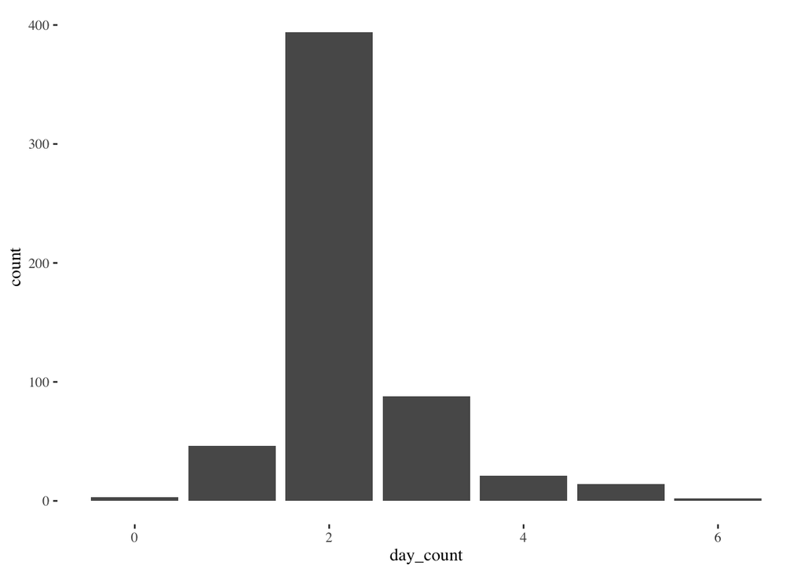

```r
# make a bar plot of day_count with x=day_count
# geom_bar() just handles this because it's default is to count the number of instances in each group (in this case, what we have put on the x-axis)

daycount_courses |>
  ggplot(aes(x=day_count)) +
  geom_bar() +
  theme_tufte()
```

## `word`

Allows you to select words from a string. The function assumes as a default that the words are separated by a space, but you can define a different separator if you need using the `sep=` argument.

```r
# let's look at the help docs
#?word

# mutate new column called building with just the first word from location

course_building <- courses |>
  mutate(building = word(location, 1)) |>
  select(titles, department, location, building)

course_building
```

```
# A tibble: 568 × 4
   titles                                           department location building
   <chr>                                            <chr>      <chr>    <chr>
 1 Cultural Community Collaboration & Production    Program i… "Wright… Wright
 2 Immigrant America                                Program i… "Axinn … Axinn
 3 Introduction to Latina/o Studies                 Program i… "Axinn … Axinn
 4 See the U.S.A.: The History of Tourism in Ameri… Program i… "Axinn … Axinn
 5 Science Fiction                                  Program i… "Axinn … Axinn
 6 Music and Social Power in American Culture       Program i… "Axinn … Axinn
 7 <NA>                                             Program i… "Axinn … Axinn
 8 Viewer Discretion Advised: Controversies in Ame… Program i… "Axinn … Axinn
 9 Posthuman Medicine: Morals, Machines, and Bodies Program i… "Axinn … Axinn
10 Humanitarian Visas in Vermont and Beyond         Program i… "Axinn … Axinn
# ℹ 558 more rows
```

Let’s make a plot using some of the columns we’ve just made:

```r
# what should we plot???

# count the number of words in the description
# we do this by counting the number of spaces and then adding 1
# use str_count() with  pattern=" " to count spaces

course_desc <- courses |>
  mutate(word_count= str_count(description, " ") + 1) |>
  select(titles, department, word_count, description)

course_desc
```

```
# A tibble: 568 × 4
   titles                                      department word_count description
   <chr>                                       <chr>           <dbl> <chr>
 1 Cultural Community Collaboration & Product… Program i…        120 "\nIn this…
 2 Immigrant America                           Program i…         91 "\nIn this…
 3 Introduction to Latina/o Studies            Program i…         89 "\nIn this…
 4 See the U.S.A.: The History of Tourism in … Program i…        165 "\nIn this…
 5 Science Fiction                             Program i…        141 "\nTime tr…
 6 Music and Social Power in American Culture  Program i…        121 "\nAlthoug…
 7 <NA>                                        Program i…         NA  <NA>
 8 Viewer Discretion Advised: Controversies i… Program i…        130 "\nWhat ar…
 9 Posthuman Medicine: Morals, Machines, and … Program i…        118 "\nMedical…
10 Humanitarian Visas in Vermont and Beyond    Program i…         70 "\nThis pu…
# ℹ 558 more rows
```

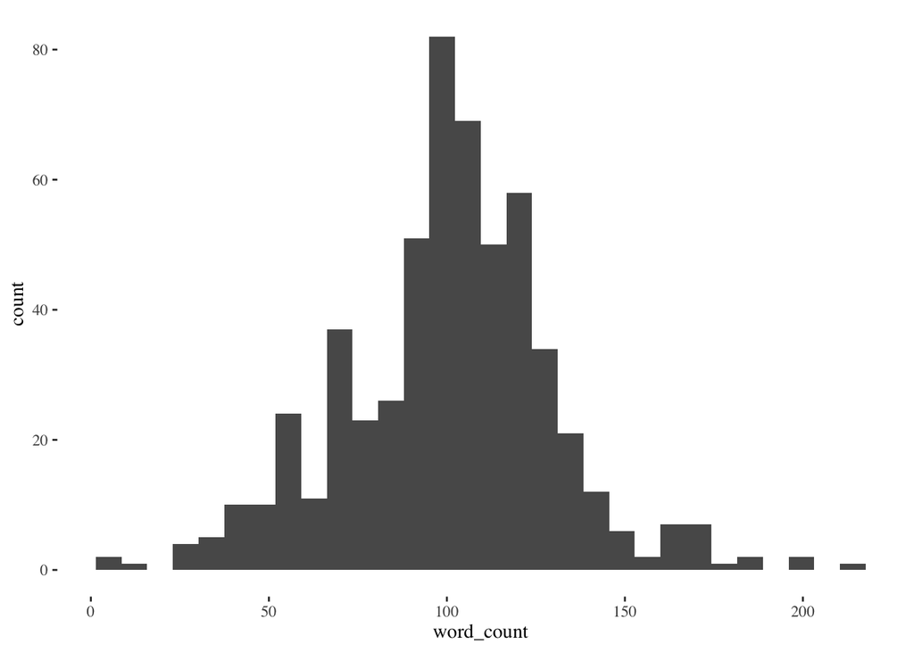

```r
# make a histogram of the results

course_desc |>
  ggplot(aes(x=word_count)) +
  geom_histogram() +
  theme_tufte()
```

Let’s make a figure to visualize word count in course descriptions by department to see which departments have the longest and which have the shortest course descriptions.

I’m going to make a ridgeline plot using the `ggridges` package. This can be a fun way to visualize a shifting data distribution based on category.

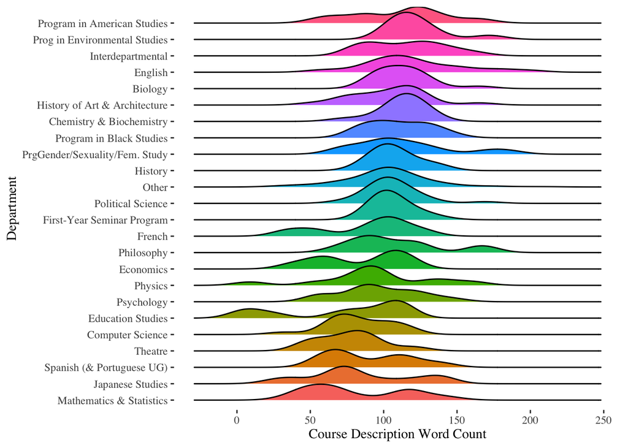

```r
# Now I'm wondering which courses have the longest descriptions


# Now I want to know how the word count distribution changes by department
library(ggridges)
# let's try for a ridgeline plot with the departments in order by max word count in their description
# use geom_density_ridges()
# use fct_lump_min() to lump departments with less than 10 instances
# fct_reorder(,.fun=max) to reorder

course_desc |>
  filter(word_count > 0) |> #remove any instances where course description is absent
  mutate(dept_factor = factor(department), #turn department into a factor
         dept_factor = fct_lump_min(dept_factor, 10), #lump together departments with fewer than 10 courses
         dept_factor = fct_reorder(dept_factor, word_count, .fun="median")) |> # reorder factor by median word count
  ggplot(aes(x=word_count, y=dept_factor, fill=dept_factor)) +
  geom_density_ridges() +
  labs(x="Course Description Word Count",
       y="Department") +
  theme_tufte() +
  theme(legend.position="none") # suppress legend
```